# DHARMa: residual diagnostics for hierarchical (multi-level/mixed) regression models

# Case studies and examples

**Note:** More real-world examples on the DHARMa GitHub repository [here](https://github.com/florianhartig/DHARMa/tree/master/Code/Examples)

## Budworm example (count-proportion n/k binomial)

This example comes from [Jochen Fründ](https://jochenfruend.wordpress.com/). Measured are the number of parasitized observations, with population density as a covariate

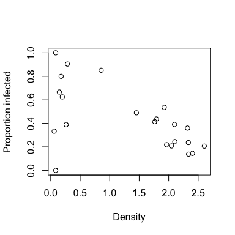

```r
plot(N_parasitized / (N_adult + N_parasitized ) ~ logDensity, xlab = "Density", ylab = "Proportion infected", data = data)
```

Let’s fit the data with a regular binomial n/k glm

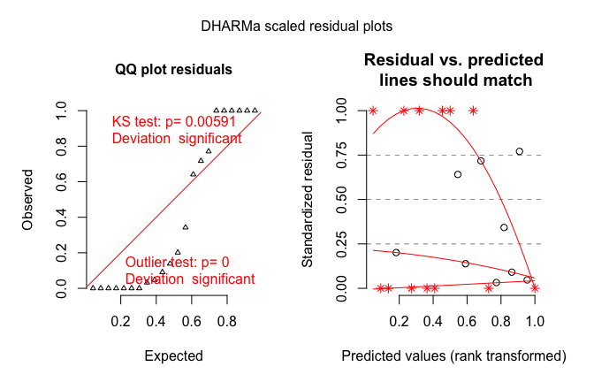

```r
mod1 <- glm(cbind(N_parasitized, N_adult) ~ logDensity, data = data, family=binomial)
simulationOutput <- simulateResiduals(fittedModel = mod1)
plot(simulationOutput)
```

The residuals look clearly overdispersed. We can confirm that with the omnibus test

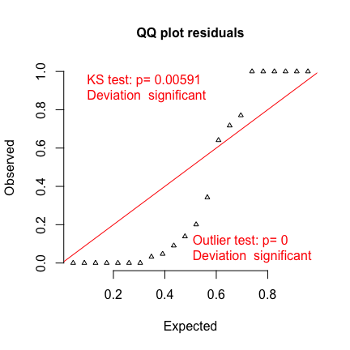

```
##
##  One-sample Kolmogorov-Smirnov test
##
## data:  simulationOutput$scaledResiduals
## D = 0.36382, p-value = 0.005911
## alternative hypothesis: two-sided
```

```r
testUniformity(simulationOutput = simulationOutput)
```

Or with the more powerful overdispersion test

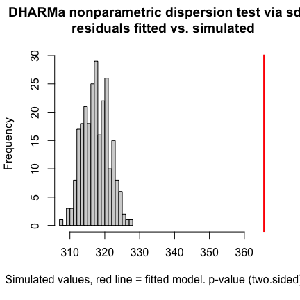

```
##
##  DHARMa nonparametric dispersion test via sd of residuals fitted
##  vs. simulated
##
## data:  simulationOutput
## ratioObsSim = 1.1516, p-value < 2.2e-16
## alternative hypothesis: two.sided
```

```r
testOverdispersion(simulationOutput = simulationOutput)
```

OK, so let’s add overdispersion through an individual-level random effect

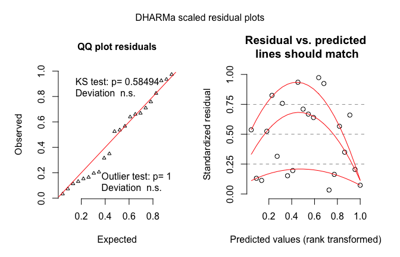

```r
mod2 <- glmer(cbind(N_parasitized, N_adult) ~ logDensity + (1|ID), data = data, family=binomial)
simulationOutput <- simulateResiduals(fittedModel = mod2)
plot(simulationOutput)
```

The overdispersion looks better, but you can see that the residuals look a bit irregular.

Likely, the reason is the steep increase in the beginning that one can see in the raw data plot. One would probably need to apply another transformation or a nonlinear function to completely fit this away.

## Owl example (count data)

The next examples uses the fairly well known Owl dataset which is provided in glmmTMB (see ?Owls for more info about the data).

The following shows a sequence of models, all checked with DHARMa. The example is discussed in a talk at ISEC 2018, see slides [here](https://www.slideshare.net/florianhartig/mon-c5hartig2493).

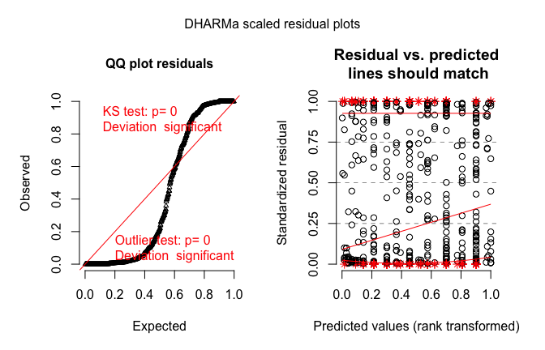

```r
m1 <- glm(SiblingNegotiation ~ FoodTreatment*SexParent + offset(log(BroodSize)), data=Owls , family = poisson)
res <- simulateResiduals(m1)
plot(res)
```

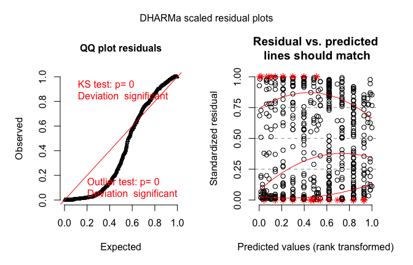

```r
m2 <- glmer(SiblingNegotiation ~ FoodTreatment*SexParent + offset(log(BroodSize)) + (1|Nest), data=Owls , family = poisson)
res <- simulateResiduals(m2)
plot(res)
```

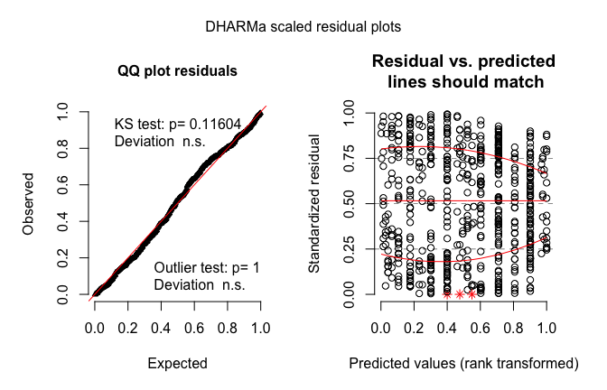

```r
m3 <- glmmTMB(SiblingNegotiation ~ FoodTreatment*SexParent + offset(log(BroodSize)) + (1|Nest), data=Owls , family = nbinom1)
res <- simulateResiduals(m3)
plot(res)
```

```r
summary(m3)
```

```
##  Family: nbinom1  ( log )
## Formula:
## SiblingNegotiation ~ FoodTreatment * SexParent + offset(log(BroodSize)) +
##     (1 | Nest)
## Data: Owls
##
##      AIC      BIC   logLik deviance df.resid
##   3400.8   3427.2  -1694.4   3388.8      593
##
## Random effects:
##
## Conditional model:
##  Groups Name        Variance Std.Dev.
##  Nest   (Intercept) 0.1265   0.3556
## Number of obs: 599, groups:  Nest, 27
##
## Overdispersion parameter for nbinom1 family (): 7.05
##
## Conditional model:
##                                     Estimate Std. Error z value Pr(>|z|)
## (Intercept)                          0.67674    0.11340   5.968 2.41e-09
## FoodTreatmentSatiated               -0.87038    0.13964  -6.233 4.58e-10
## SexParentMale                        0.04469    0.10712   0.417    0.677
## FoodTreatmentSatiated:SexParentMale  0.12173    0.17520   0.695    0.487
##
## (Intercept)                         ***
## FoodTreatmentSatiated               ***
## SexParentMale
## FoodTreatmentSatiated:SexParentMale
## ---
## Signif. codes:  0 '***' 0.001 '**' 0.01 '*' 0.05 '.' 0.1 ' ' 1
```

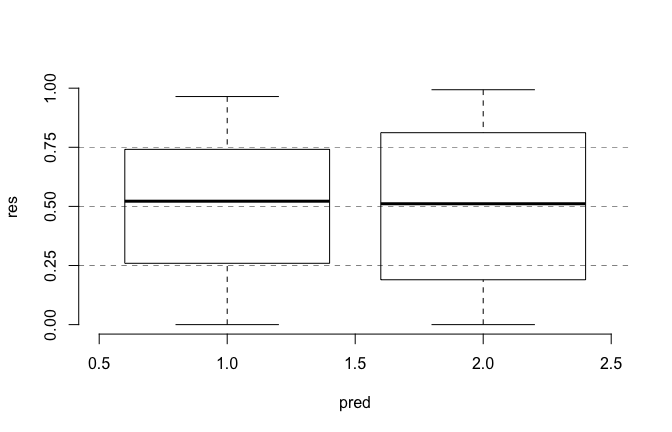

```r
plotResiduals(Owls$FoodTreatment, res$scaledResiduals)
```

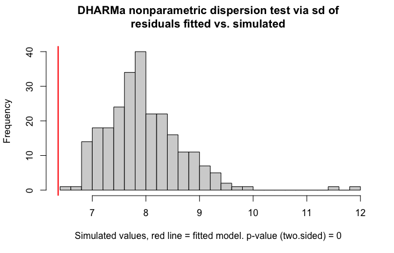

```
##
##  DHARMa nonparametric dispersion test via sd of residuals fitted
##  vs. simulated
##
## data:  simulationOutput
## ratioObsSim = 0.79972, p-value < 2.2e-16
## alternative hypothesis: two.sided
```

```r
testDispersion(res)
```

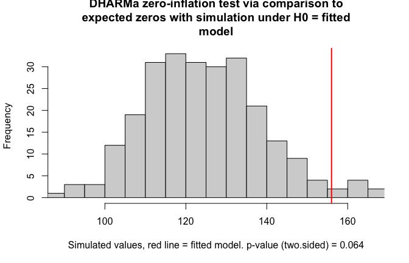

```
##
##  DHARMa zero-inflation test via comparison to expected zeros with
##  simulation under H0 = fitted model
##
## data:  simulationOutput
## ratioObsSim = 1.2488, p-value = 0.064
## alternative hypothesis: two.sided
```

```r
testZeroInflation(res)
```

```r
m4 <- glmmTMB(SiblingNegotiation ~ FoodTreatment*SexParent + offset(log(BroodSize)) + (1|Nest), ziformula = ~ FoodTreatment + SexParent,  data=Owls , family = nbinom1)
summary(m4)
```

```
##  Family: nbinom1  ( log )
## Formula:
## SiblingNegotiation ~ FoodTreatment * SexParent + offset(log(BroodSize)) +
##     (1 | Nest)
## Zero inflation:                      ~FoodTreatment + SexParent
## Data: Owls
##
##      AIC      BIC   logLik deviance df.resid
##   3361.0   3400.6  -1671.5   3343.0      590
##
## Random effects:
##
## Conditional model:
##  Groups Name        Variance Std.Dev.
##  Nest   (Intercept) 0.07114  0.2667
## Number of obs: 599, groups:  Nest, 27
##
## Overdispersion parameter for nbinom1 family (): 4.07
##
## Conditional model:
##                                     Estimate Std. Error z value Pr(>|z|)
## (Intercept)                          0.79147    0.09841   8.042 8.82e-16
## FoodTreatmentSatiated               -0.42028    0.14476  -2.903  0.00369
## SexParentMale                       -0.06593    0.09886  -0.667  0.50481
## FoodTreatmentSatiated:SexParentMale  0.11693    0.16948   0.690  0.49022
##
## (Intercept)                         ***
## FoodTreatmentSatiated               **
## SexParentMale
## FoodTreatmentSatiated:SexParentMale
## ---
## Signif. codes:  0 '***' 0.001 '**' 0.01 '*' 0.05 '.' 0.1 ' ' 1
##
## Zero-inflation model:
##                       Estimate Std. Error z value Pr(>|z|)
## (Intercept)            -2.0325     0.3084  -6.590 4.40e-11 ***
## FoodTreatmentSatiated   1.5427     0.2998   5.146 2.66e-07 ***
## SexParentMale          -0.4902     0.2740  -1.789   0.0736 .
## ---
## Signif. codes:  0 '***' 0.001 '**' 0.01 '*' 0.05 '.' 0.1 ' ' 1
```

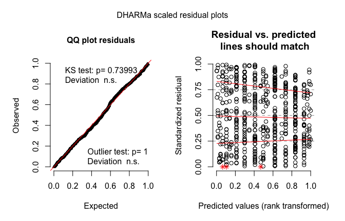

```r
res <- simulateResiduals(m4)
plot(res)
```

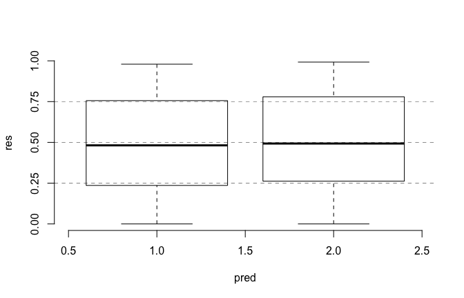

```r
plotResiduals(Owls$FoodTreatment, res$scaledResiduals)
```

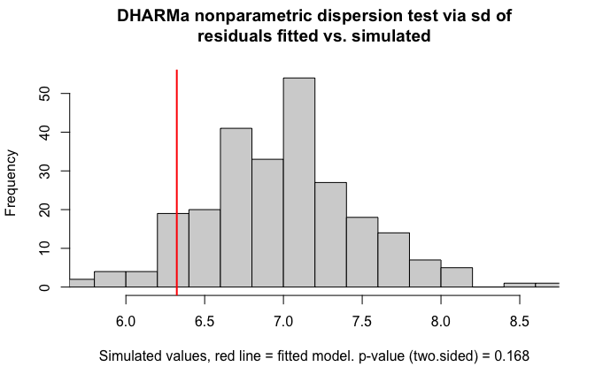

```
##
##  DHARMa nonparametric dispersion test via sd of residuals fitted
##  vs. simulated
##
## data:  simulationOutput
## ratioObsSim = 0.90405, p-value = 0.168
## alternative hypothesis: two.sided
```

```r
testDispersion(res)
```

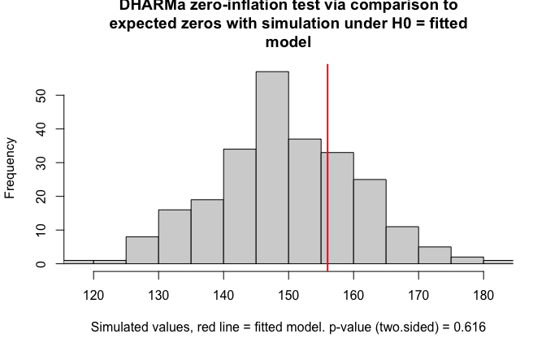

```
##
##  DHARMa zero-inflation test via comparison to expected zeros with
##  simulation under H0 = fitted model
##
## data:  simulationOutput
## ratioObsSim = 1.0389, p-value = 0.616
## alternative hypothesis: two.sided
```

```r
testZeroInflation(res)
```

```r
m5 <- glmmTMB(SiblingNegotiation ~ FoodTreatment*SexParent + offset(log(BroodSize)) + (1|Nest), dispformula = ~ FoodTreatment , ziformula = ~ FoodTreatment + SexParent,  data=Owls , family = nbinom1)
summary(m5)
```

```
##  Family: nbinom1  ( log )
## Formula:
## SiblingNegotiation ~ FoodTreatment * SexParent + offset(log(BroodSize)) +
##     (1 | Nest)
## Zero inflation:                      ~FoodTreatment + SexParent
## Dispersion:                          ~FoodTreatment
## Data: Owls
##
##      AIC      BIC   logLik deviance df.resid
##   3353.0   3397.0  -1666.5   3333.0      589
##
## Random effects:
##
## Conditional model:
##  Groups Name        Variance Std.Dev.
##  Nest   (Intercept) 0.08695  0.2949
## Number of obs: 599, groups:  Nest, 27
##
## Conditional model:
##                                     Estimate Std. Error z value Pr(>|z|)
## (Intercept)                          0.79825    0.09511   8.393  < 2e-16
## FoodTreatmentSatiated               -0.47113    0.16647  -2.830  0.00465
## SexParentMale                       -0.08524    0.09024  -0.945  0.34484
## FoodTreatmentSatiated:SexParentMale  0.12765    0.18960   0.673  0.50079
##
## (Intercept)                         ***
## FoodTreatmentSatiated               **
## SexParentMale
## FoodTreatmentSatiated:SexParentMale
## ---
## Signif. codes:  0 '***' 0.001 '**' 0.01 '*' 0.05 '.' 0.1 ' ' 1
##
## Zero-inflation model:
##                       Estimate Std. Error z value Pr(>|z|)
## (Intercept)            -1.8392     0.2912  -6.317 2.67e-10 ***
## FoodTreatmentSatiated   1.0184     0.4131   2.465   0.0137 *
## SexParentMale          -0.5722     0.3319  -1.724   0.0847 .
## ---
## Signif. codes:  0 '***' 0.001 '**' 0.01 '*' 0.05 '.' 0.1 ' ' 1
##
## Dispersion model:
##                       Estimate Std. Error z value Pr(>|z|)
## (Intercept)             1.1061     0.1460   7.578  3.5e-14 ***
## FoodTreatmentSatiated   0.8267     0.2714   3.046  0.00232 **
## ---
## Signif. codes:  0 '***' 0.001 '**' 0.01 '*' 0.05 '.' 0.1 ' ' 1
```

## Binomial 0/1 data

There are a lot of rumors about that can and cannot be checked with binomial 0/1 data. Let’s consider a clearly misspecified binomial model

```r
testData = createData(sampleSize = 500, overdispersion = 0, fixedEffects = 5, family = binomial(), randomEffectVariance = 3, numGroups = 25)
fittedModel <- glm(observedResponse ~ 1, family = "binomial", data = testData)

simulationOutput <- simulateResiduals(fittedModel = fittedModel)
```

A rumor that is true is that, unlike in k/n or count data, such a misspecification will not produce overdispersion.

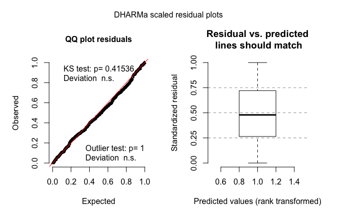

```r
plot(simulationOutput, asFactor = T)
```

However, you can clearly see the misfit if you plot

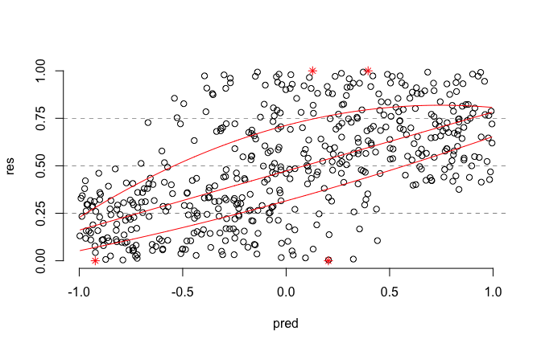

```r
plotResiduals(testData$Environment1, simulationOutput$scaledResiduals, quantreg = T)
```

Moreover, if you perform the DHARMa procedure per group, you can see overdispersion created by the random effect variance (left without grouping, right with grouping)

```r
par(mfrow = c(1,2))
testDispersion(simulationOutput)
```

```
##
##  DHARMa nonparametric dispersion test via sd of residuals fitted
##  vs. simulated
##
## data:  simulationOutput
## ratioObsSim = 1.0013, p-value = 1
## alternative hypothesis: two.sided
```

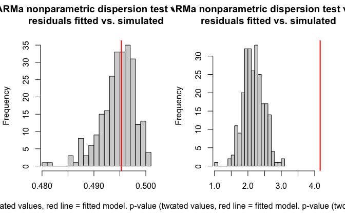

```
##
##  DHARMa nonparametric dispersion test via sd of residuals fitted
##  vs. simulated
##
## data:  simulationOutput
## ratioObsSim = 1.9212, p-value < 2.2e-16
## alternative hypothesis: two.sided
```

```r
simulationOutput = recalculateResiduals(simulationOutput , group = testData$group)
testDispersion(simulationOutput)
```